# Does Urban Granularity Effect Rents in Chicago?

Nicholas DeSante

2026-05-11

# Granularity

For millennia, cities have developed granularly. The incremental growth patterns that have historically dominated in our urban past led these cities to manifest as a cluster of small, tightly packed buildings. For the first few hundred years since their establishments, the colonies and then the United States followed this development pattern. While planners designed these cities with street grids and canals, the blocks were still filled with small-scale, tightly packed buildings. Yet, over the past 100 years, as construction technology and techniques have developed, the United States has seen a shift in its urban development style. Now, development tends to be less granular, where larger land developers with great capital build fill a block with fewer, larger buildings.

To understand this idea, let’s consider parcels, which are simply a plot of land in an urban area. When considering a city block in a granular neighborhood, that block may be composed of thirty small parcels, each with an owner. Meanwhile, in a modern development, that entire block might be composed of only a few parcels and fewer owners.

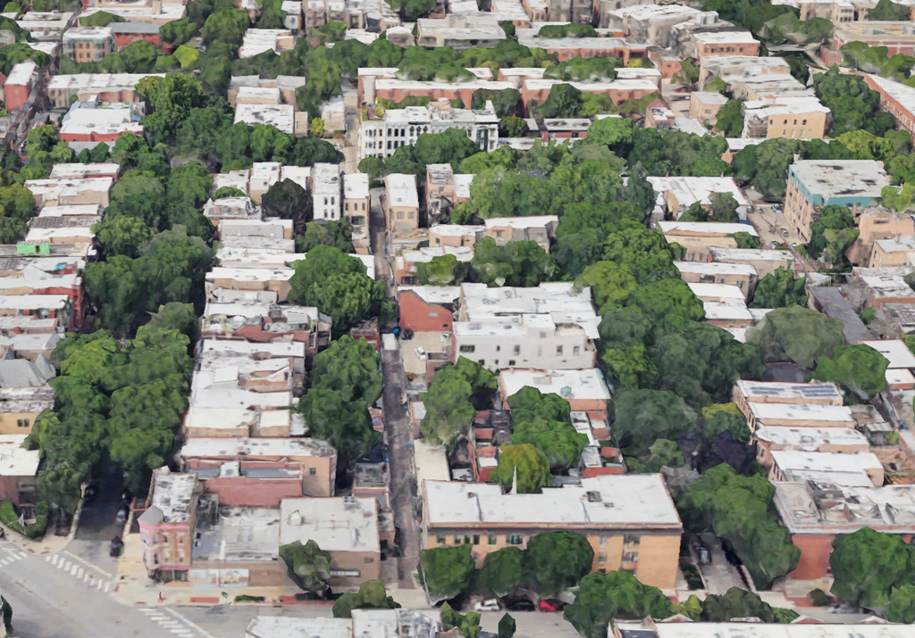

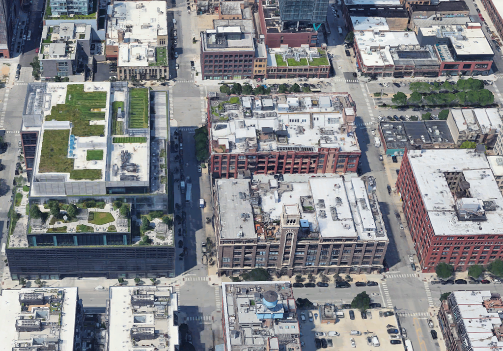

Granular (Left) vs Consolidated (Right) Development Patterns

### Why this matters

When we consider the rental housing market, prices are not uniform everywhere. Factors including location and amenities differentiate one rental from another, implying that landlords have some price-setting power. Indeed, recent research in New York City shows that landlords there do have pricing power.[^1] Therefore, as development patterns trend towards fewer, larger parcels, this may correspond to less localized competition, in turn, increasing landlords’ pricing power further.

In an era of ever-more expensive housing, understanding whether our new development framework affects housing prices is critical. Government leaders must be well-informed as they formalize new plans to fight against the current housing crisis. In addition, prices can tell us about market preferences. We may believe that differences in rents for granular vs consolidated development may reflect the value of a granular and complex neighborhood to consumers. Citizen preferences can be just as important for government leaders in their efforts to plan livable cities. Thus, we investigate below whether granularity truly makes a difference.

### Why Chicago?

Chicago is a large historic city with a mix of old and new development, making it a suitable case study for comparing traditional, granular neighborhoods to new, consolidated development. Additionally, Chicago has several other beneficial features.

1. It has rich, historical parcel data, provided by the Cook County Government.
2. It is a typical, single-center city, meaning that it fits well with the usual economic theories used to understand how rent prices change across the city.
3. It can be divided into 77 designated community areas, which the University of Chicago developed for analytical and planning uses.

# Our Parcel Density Measure

For our parcel density measure we use the total parcels per residential acre. It is calculated by dividing the total number of residential parcels by the total residential area (in acres) within a census tract. Thus, if there are ten residential parcels covering an area of ten acres, the parcel density would be one. If there are ten residential parcels covering an area of one acre, the parcel density would be 10. The more parcels that can fit within an acre, the higher the density. This approach is preferable to measuring parcel counts per acre, based on the entire tracts acreage because it excludes non-residential land use. In cities, a neighborhood often includes significant acreage dedicated to parks, industry, commerce, and infrastructure, which can bias the parcel density measure. By using residential acres as the base, we believe that parcel density better corresponds to competition.

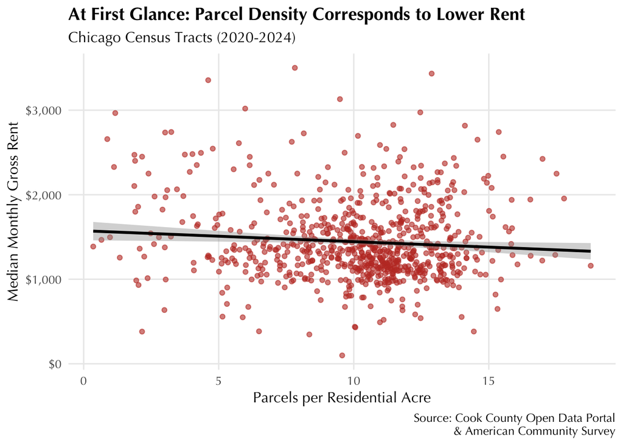

# Addressing Bias

When estimating the effect of a specific factor on our outcome, we must address bias. That means, we don’t want to conflate the effects of other factors with the effect of our factor of interest. In cities, this is particularly important due to the various factors that affect each other while affecting prices. For example, we mentioned earlier that larger parcels are a product of modern development technologies; thus, we expect neighborhoods that are less granular to be newer on average and neighborhoods that are more granular to be older on average. Since newer buildings are inherently more valuable than older ones, if we don’t account for building age, we risk incorrectly attributing the newness premium to the physical density of the parcels themselves.

Below, we present maps that demonstrate how building age corresponds to differences in rent as well as parcel density.

### Median Rent

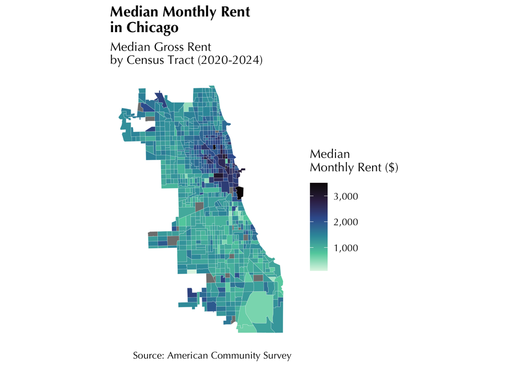

### Neigborhood Age

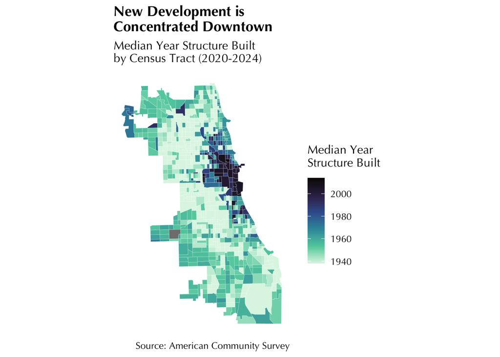

### Parcel Density

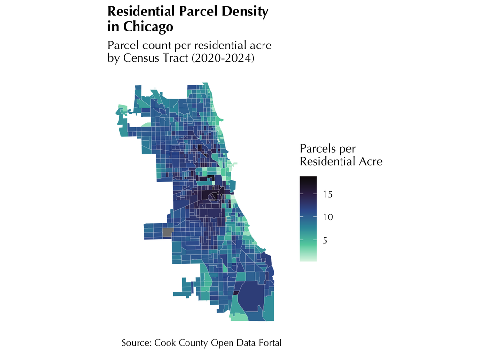

In addition to age, we account for other tract-level factors, like the total number of housing units (controlling for housing supply), the share of an area that is renter occupied (controlling for market composition), the median household income (controlling for income-driven preferences), and the share of vacant units for rent (controlling for short-term market fluctuations).

Another core control includes the tract’s distance to downtown (in miles), which accounts for differences in rents caused by the proximity to Chicago’s business and commercial center. As mentioned above, Chicago is a typical, single-center city, which aligns with traditional urban economic theory. Under a single-center city model, rents are highest at the center (downtown) and decrease at a diminishing rate as the distance from the center increases. Thus, to correctly account for our control’s effect on prices, we calculate both the distance and the squared distance.

We can go even further by using a technique called fixed effects, which allows us to look at trends across different groups. This technique shifts our focus from between-group to within-group variation, allowing us to control for varying rental baselines that could otherwise lead to misleading interpretations at the city-wide level. We use Chicago’s 77 designated community areas for our fixed effects to account for unobservable and difficult-to-account-for differences between neighborhoods.

See below, a map of Chicago’s 77 community areas:

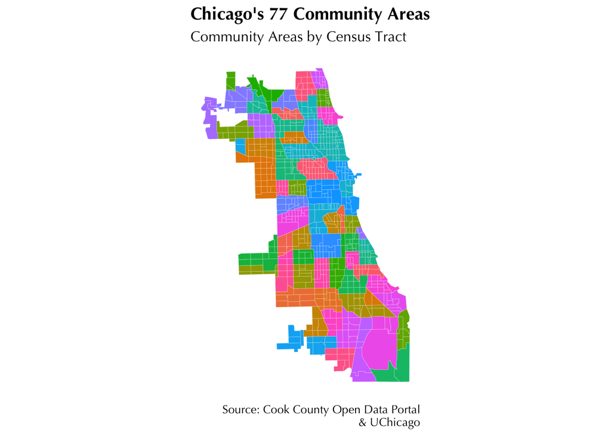

# Addressing Bias Through Bedrock

Even with our controls and fixed effects, we think we can go even further to address bias using an instrumental variable technique. This technique uses a random variable (the instrument) that affects parcel density and, in turn, affects rents. When done correctly, we get a bias-free result. We use an instrument in addition to fixed effects and controls because we want to account for additional unobserved factors at the tract-level that cause bias.

For our instrument, we use the average depth to bedrock (in feet) for Chicago from the International Soil Reference and Information Centre (ISRIC). We chose the depth to bedrock as an instrument because we believe that it meets two requirements. First, that the instrument is relevant, that is, the depth to bedrock affects parcel density. Second, that the instrument is exogenous, that is, it is not associated with other factors that influence rent.

We believe bedrock depth is relevant because depth to bedrock determines how easy it is to build larger, taller, and heavier buildings. The deeper you go, the more difficult it is to build, leading us to expect fewer large deployments, more smaller deployments, and higher parcel density.

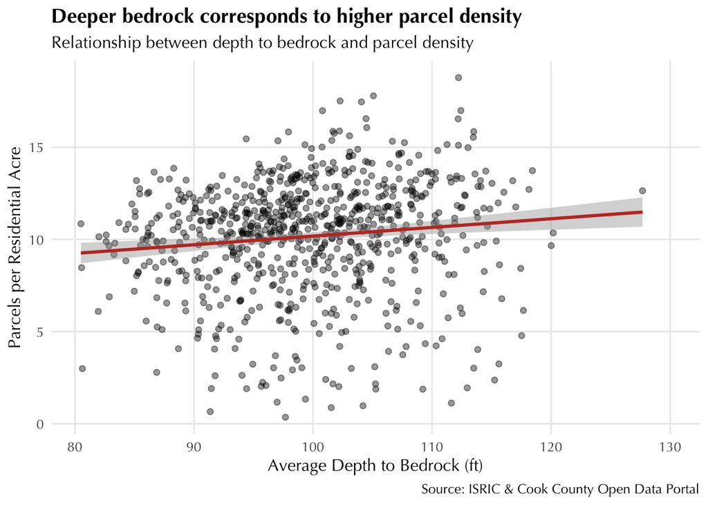

We believe bedrock depth is exogenous because it is a historic geological feature formed millions of years ago, and which changes slowly over the course of hundreds of thousands of years. This factor isn’t related to modern amenities, school districts, or migration trends, and thus, we believe it does not directly affect rental prices except through its influence on how the land was developed.

[interactive chart not shown]

### A look back at our plots from earlier

Deeper bedrock seems to correspond to higher rents. Many of these tracts have higher parcel densities, but there are also many at lower parcel density levels.

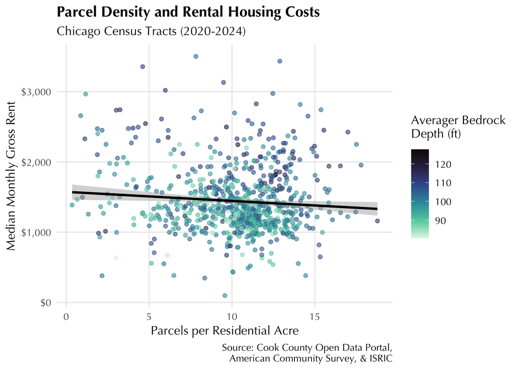

### Bedrock Depth

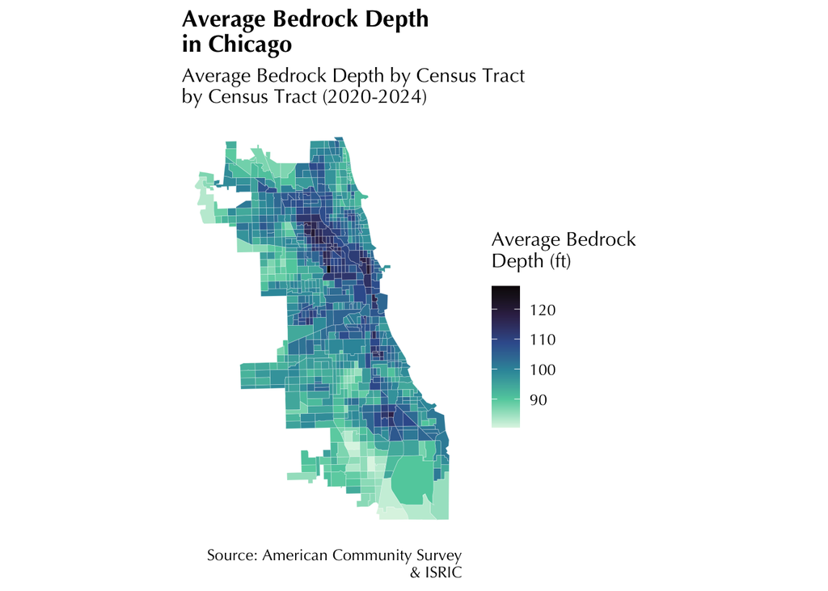

### Parcel Density

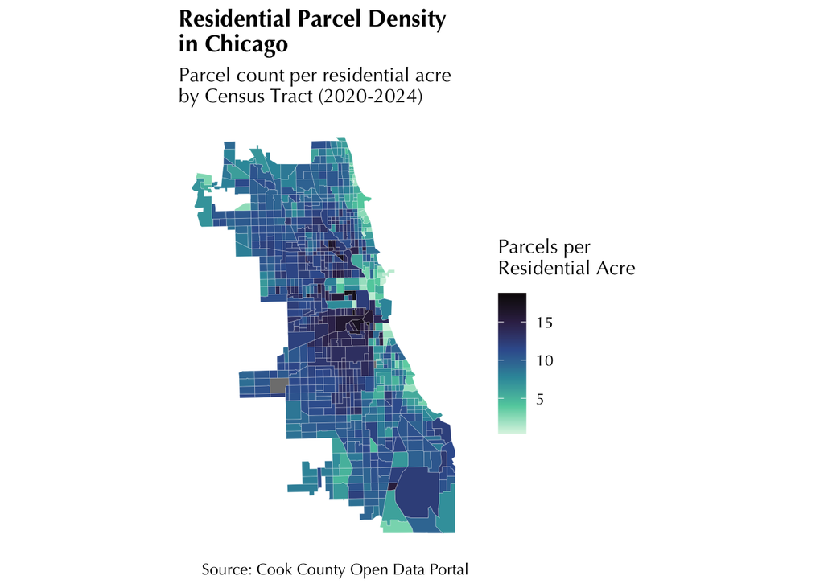

### Median Rent

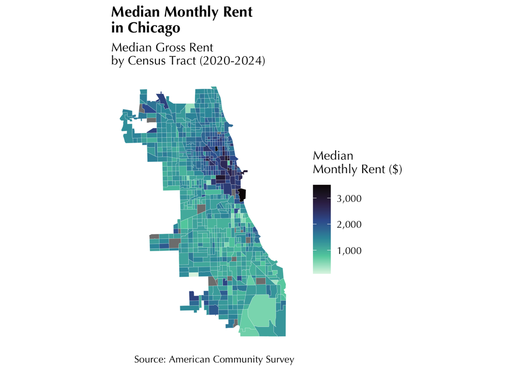

Visually, it is difficult to interpret the relationship between bedrock depth, parcel density, and rents. This observation may be a harbinger of a weak instrument. Despite this, the statistical checks we conducted to test for relevancy held up, giving us confidence that bedrock depth affects parcel density. Therefore, to use the instrument, we now only have to rely on our theoretical argument that depth isn’t related to other factors.

# The Challenge of Precision

### Analyzing the effects of parcel density

Precision refers to the variability of data, where estimates with high precision correspond to low variability and smaller standard error, leading to greater confidence in our estimates.

When analyzing cities, we cannot assume that each census tract is independent of another. Because the census tracts within each of Chicago’s community areas are geographically adjacent, they will share unobserved characteristics. While we have accounted for the bias, we also must account for variance. Thus, we utilize clustered standard errors to allow variance to reflect the correlation of errors, providing us with less precise, more conservative test statistics.

Going further, for both are fixed effects and instrumental variable techniques, we have a trade-off between improved unbiasedness and reduced precision. Spatial fixed effects decrease precision because focusing only on variation within community areas, rather than across the entire city, reduces the available variation. Similarly, our instrumental variable reduces our precision because we focus only on the specific variation of parcel density that is explained by the instrument.

Below, we see how all these factors together produce statistically insignificant results for all four of our model specifications (simple regression, multiple regression, fixed effects, and instrumental variable).

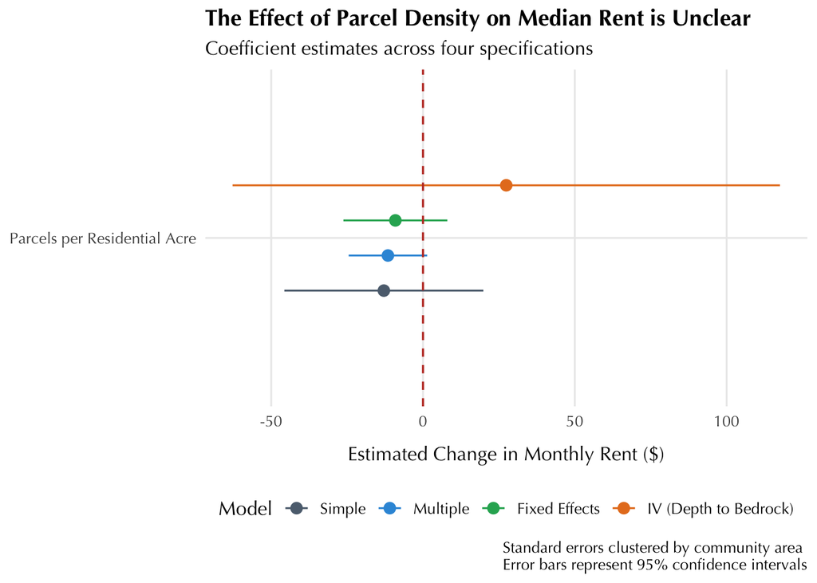

Ultimately, our results show the challenge of identifying causal effects in the highly interrelated framework of urban economics. Given that our standard models, fixed effects, and instrument strategies were imprecise, we cannot determine an effect. In fact, an effect may be nonexistent. While we used parcel density as a proxy for localized competition, it is possible that this metric does not fully capture the complex nature of market power and competition in urban environments. Even so, our models show no clear indication of a market preference or distaste for granularity either. Ultimately, we demonstrate that, although an effect may seem apparent on the surface, deeper analysis can reveal a more complex story. Sometimes, in pursuit of the truth, you find no effect.

# Where do we go from here?

One thing is clear: Further research is needed.

Although these results do not provide substantial takeaways with regard to the urban form that policymakers should keep in mind, they highlight the need for new policies that improve data collection in cities, especially for housing markets. To address the rising cost of housing, we must facilitate increased investigation in this field through many novel approaches. More reliable data could catalyze this investigation and help researchers make important breakthroughs that will aid in future policy decisions.

# Endnotes

[^1]: C. Luke Watson and Oren Ziv, “A Test for Pricing Power in Urban Housing Markets,” Review of Economics and Statistics, December 18, 2025, 1–33, https://doi.org/10.1162/rest.a.1687.